# Tutorial to train, evaluate, and project Species Distribution Models for benthic organisms using the ‘biomod2’ package

Damiano Baldan

2025-05-28

# Content

This document is a step-by-step tutorial to fit Species Distribution Models (SDMs) for benthic organisms using the ‘biomod2’ package. The main steps of the tutorial will describe how to pre-process the environmental data, fit SDMs, evaluate SDMs, and project SDMs to generate habitat suitability maps.

# 1. Introduction

This markdown document provides a tutorial to fit Species Distribution Models (SDMs) for benthic organisms in the Mediterranean Sea. Species Distribution Models are correlative methods that employ machine learning algorithms to infer the (realized) ecological niche of organism based on occurrence data and environmental covariates (predictors). For a review of SDMs, see Elith & Leathwick (2009) and Pichler & Hartig (2023). The algorithms, workflow, and an application are described in details in Baldan et al. (2024).

In this document, models are fitted for *Posidonia oceanica*, a keystone species in the Mediterranean Sea. However, the workflow is general and can be implemented for any species.

The source code used to generate this tutorial is available on [github](https://github.com/damianobaldan/benthic_habitat_scripts) in the file benthic_habitat_scripts.Rmd; additional functions used in the tutorial are stored in the file benthic_habitat_utility_funs.R.

## 1.1 Modeling approach and algorithms

The modeling approach used in this document is based on model ensembling, where several types of modeling algorithms are fitted to different subsets of data and a final ensemble model is then assembled based on the single model’s performances. In this tutorial, four types of modeling algorithms with different complexitties (Pichler & Hartig, 2023) are used:

- Generalized Linear Models (GLM),
- Generalized Additive Models (GAM),
- Random Forest (RF),
- Artificial Neural Networks (ANN).

Additional dimensions of variability between the fitted models are the pseudoabsence data and the evaluation method:

- Since no independent evaluation dataset exists, cross validation has to be used to assess each model’s performance. Here, 5-fold cross validation is used, and repeated three times with different randomized folds. A spatial blocks approach is used to assess the ensemble performances over an independent dataset, see below for details. In short, first a training and an evaluation datasets are created based on spatial blocks. Then the training dataset is splitted using a 5-fold cross-validation approach where models are calibrated on 4 folds and validated on the remaining one. The performance of the models on the validation fold is giving relevant information on the ability of the single model to perform well on a separate dataset. However, the ensemble is built with all the models, and this contains information from all the training dataset. Thus, there is the need for an additional evaluation dataset.
- Since no true absence data are available, an algorithm was used to randomly generate pseudo-absences (P-abs). The procedure was repeated three times to generate three P-abs sets used to fit the models.

In conclusion, a total number of: 4 (modeling algorithms) X 5 (cross-validation folds) X 3 (cross-validation repetitions) X 3 (P-abs datasets) = 180 models were fitted and used for the ensemble generation.

## 1.2 Dependencies

This tutorial used the `biomod2` package (Thuiller et al., 2009) to fit and evaluate SDMS. Few other libraries are needed: `terra` and for raster data and `sf` for shapefile data manipulation, `spatstat` for spatial analyses needed for P-abs processing, `ecospat` for model’s performances (Boyce’s index), `cluster` and `NMOF` for the ensemble evaluation, `ggdendro` and `ggtext` for plotting the predictors dendrogram, `usdm` for the Variance Inflation Factor analysis function, `viridis` for nice palettes for plotting.

Some custom functions are also used and are stored in the file benthic_habitat_utility_funs.R. In particular, the function `make_blocks` was developed by Philipp Brun and used in the Brun et al. (2020) paper. If this function is used, the Brun (2020) paper must be cited.

```r
library(terra)
library(sf)
library(tidyverse)
library(biomod2)
library(tidyterra)
library(spatstat)
library(ecospat)
library(cluster)
library(NMOF)
library(ggdendro)
library(ggtext)
library(usdm)
library(viridis)
library(tidyterra)

source("benthic_habitat_utility_funs.R")
```

# 2. Input Data

Occurrence data retrieved from the literature are used as respinse. A large number of layers of environmental covariates to be used as predictors was also assembled.

## 2.1 Environmental Covariates Layers

Most of the environmental predictors used to fit SDMs were obtained from the re-analysis of the Mediterranean Sea physics (Escudier et al. 2020, 2021), biogeochemistry (Cossarini et al. 2021; Teruzzi et al. 2021) and sea waves (Korres et al. 2021) provided by the Copernicus Marine Service ([CMS](https://marine.copernicus.eu/); Le Traon et al. 2019). The physics and biogeochemistry re-analysis products have a resolution of ~4.5×4.5 km and 125 unevenly spaced active vertical layers (thickness ranging between 2 and 100 m, increasing with depth). Data with a monthly resolution for the period 2000–2020 were downloaded. The extracted physical variables included sea water velocity (vm), potential temperature (thetao) and salinity concentration (sal). The extracted biogeochemical variables included pH (ph), concentrations of ammonium (nh4), nitrate (no3), phosphate (po4), dissolved oxygen (o2), chlorophyll (chla) and phytoplankton expressed as carbon (phy). The extracted sea waves variables included the wave significant height (whm0) and the wave mean period from variance spectral density second frequency moment (vtm02). For all physical and biogeochemical variables, the physicochemical conditions of the vertical layer just above sea bottom were considered. Finally, for all variables, the cell by cell median, maximum, minimum and range of their physicochemical conditions over the 240 monthly maps covering the 20-year period were computed and used as predictors for the models. Additionally, the high-resolution [GEBCO](https://www.gebco.net/data-products/gridded-bathymetry-data) bathymetric map (0.5×0.5 km; Weatherall et al. 2015) was used to calculate the average depth (gebco_mean_depth) and slope (gebco_mean_slope) of each 4.5×4.5 km grid cell. Finally, we retained only the fraction of the Mediterranean corresponding to a depth shallower than 40 m, as *Posidonia oceanica* only inhabits coastal regions.

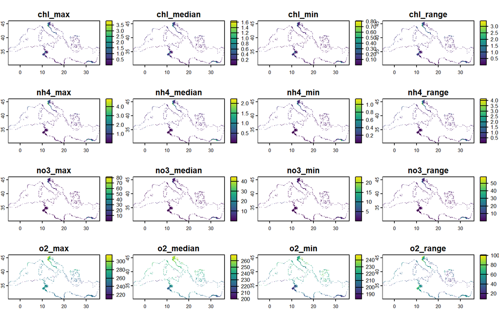

```r
myExpl <- "input_data/predictors.tif" %>% terra::rast()

myExpl
## class       : SpatRaster
## dimensions  : 380, 1005, 50  (nrow, ncol, nlyr)
## resolution  : 0.04166667, 0.04166667  (x, y)
## extent      : -5.5625, 36.3125, 30.16667, 46  (xmin, xmax, ymin, ymax)
## coord. ref. : lon/lat WGS 84 (EPSG:4326)
## source      : predictors.tif
## names       :      chl_max,   chl_median,      chl_min,    chl_range,      nh4_max,   nh4_median, ...
## min values  : 2.697762e-09, 5.454928e-12, 5.625128e-13, 2.696023e-09, 0.0009752262, 5.054907e-05, ...
## max values  : 4.098988e+00, 1.855823e+00, 9.358611e-01, 3.682963e+00, 6.3306326866, 2.564143e+00, ...

plot(myExpl)
```

## 2.2 Environmental Covariates Correlation Analysis

Some correlative methods perform poorly when correlated predictors are used. To retain a parsimonious subset of predictors for fitting the model and avoid overfitting, a hierarchical cluster analysis based on a distance matrix was performed, where 1 minus the absolute value of Spearman’s correlation coefficient (1−|r|) was used as a measure of predictor’s dissimilarity. The threshold of r = 0.7 was used to identify 17 clusters of predictors and retained one predictor for each cluster.

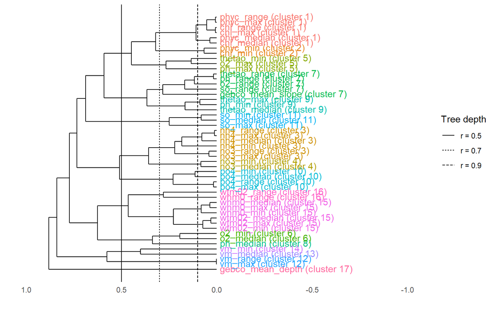

```r
# Calculate correlation between raster stack layers
funcor = function(x,y){cor(x,y, method = "spearman", use = "complete.obs")}
env_corr <- layerCor(myExpl, fun = funcor)
rownames(env_corr) <- colnames(env_corr) <- names(myExpl)

# Perform hierarchic clustering
dissimilarity = 1 - abs(env_corr)
distance <- as.dist(dissimilarity)
tree <- hclust(distance, "average")

# For plotting: cut dendrogram where spearman = 0.7
ct <- cutree(tree, h = 1- 0.7)
split(names(ct), ct)
## $`1`
## [1] "chl_max"     "chl_median"  "chl_range"   "phyc_max"    "phyc_median"
## [6] "phyc_range"
##
## $`2`
## [1] "chl_min"  "phyc_min"
##
## $`3`
## [1] "nh4_max"    "nh4_median" "nh4_min"    "nh4_range"  "no3_max"
## [6] "no3_range"
##
## $`4`
## [1] "no3_median" "no3_min"
##
## $`5`
## [1] "o2_max"     "ph_max"     "thetao_min"
##
## $`6`
## [1] "o2_median" "o2_min"
##
## $`7`
## [1] "o2_range"         "ph_range"         "so_range"         "thetao_range"
## [5] "gebco_mean_slope"
##
## $`8`
## [1] "ph_median"
##
## $`9`
## [1] "ph_min"        "thetao_max"    "thetao_median"
##
## $`10`
## [1] "po4_max"    "po4_median" "po4_min"    "po4_range"
##
## $`11`
## [1] "so_max"    "so_median" "so_min"
##
## $`12`
## [1] "vm_max"   "vm_range"
##
## $`13`
## [1] "vm_median"
##
## $`14`
## [1] "vm_min"
##
## $`15`
## [1] "whm0_max"     "whm0_median"  "whm0_min"     "wtm02_max"    "wtm02_median"
## [6] "wtm02_min"
##
## $`16`
## [1] "whm0_range"  "wtm02_range"
##
## $`17`
## [1] "gebco_mean_depth"
clust.df <- data.frame(label=names(ct), cluster=factor(ct))

# For plotting: generate dendrogram labels
tree_data <- dendro_data(tree)
labs <- label(tree_data) %>%
  left_join(clust.df) %>%
  dplyr::mutate(label2 = paste0(label, " (cluster ",cluster,")"))

# For plotting: diplay cuts at different correlation levels
df_cuts <- data.frame("cut" = c(0.5, 0.7, 0.9)) %>%
  mutate(label = paste0("r = ", cut))


# Dendrogram plot
ggplot(segment(tree_data)) +
  geom_segment(aes(x=x, y=y, xend=xend, yend=yend)) +
  geom_richtext(data=labs,
            aes(label=label2, x=x, y=0, colour=cluster), hjust = 0,
            fill = NA, label.color = NA) +
  theme_dendro() +
  coord_flip() +
  scale_y_reverse(limits = c(1, -1)) +
  geom_hline(data = df_cuts, aes(yintercept = 1 - cut, linetype = label) ) +
  scale_linetype_discrete(name = "Tree depth") +
  guides(color="none") +
  theme(axis.text.x = element_markdown() )
```

Finally, the Variance Inflation Factor (VIF, function `usdm::vifstep`) was used to identify potentially collinear predictors.

```r
# Check vifstep
myExpl %>%
  dplyr::select(
   no3_median,
   po4_median,
   chl_median,
   thetao_min,
   gebco_mean_slope,
   thetao_median,
   so_median,
   o2_median,
   ph_median,
   whm0_median,
   vm_median,
   gebco_mean_depth
   ) %>%
  usdm::vifstep()
## No variable from the 12 input variables has collinearity problem.
##
## The linear correlation coefficients ranges between:
## min correlation ( gebco_mean_depth ~ so_median ):  -0.003388383
## max correlation ( o2_median ~ thetao_min ):  -0.7372904
##
## ---------- VIFs of the remained variables --------
##           Variables      VIF
## 1        no3_median 3.659610
## 2        po4_median 4.984628
## 3        chl_median 3.053656
## 4        thetao_min 4.500697
## 5  gebco_mean_slope 2.284363
## 6     thetao_median 8.976709
## 7         so_median 2.668004
## 8         o2_median 7.392022
## 9         ph_median 4.540379
## 10      whm0_median 2.041538
## 11        vm_median 1.237410
## 12 gebco_mean_depth 1.586471
```

The procedure resulted in a short list of 12 uncorrelated and non-collinear predictors which were used as covariates in the modeling procedure.

```r
# Check vifstep
myExpl <- myExpl %>%
  dplyr::select(
   no3_median,
   po4_median,
   chl_median,
   thetao_min,
   gebco_mean_slope,
   thetao_median,
   so_median,
   o2_median,
   ph_median,
   whm0_median,
   vm_median,
   gebco_mean_depth
   )
```

## 2.3 Occurrence Data

Occurrence points for *P. oceanica* were retrieved from Chefaoui et al. (2017). The datasets contains 1140 georeferenced points. Considering the spatial resolution of CMS Mediterranean products, occurrences were pre-processed by retaining only one occurrence point per 4.5×4.5 km grid cell, resulting in 640 points used to fit the models. This procedure is referred to as rarefaction or thinning and is widely used to solve fine-scale autocorrelation in the data. Several libraries in R implement functions to perform this operation, for example the package `GeoThinneR`.

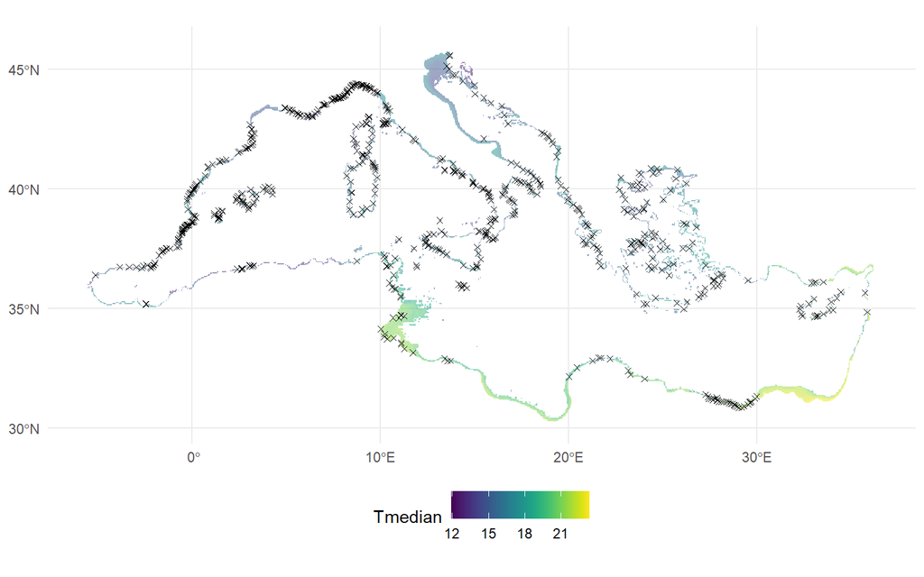

```r
# Check vifstep
DataSpecies <- "input_data/Posidonia_oceanica_paper___snap.shp" %>%
  st_read(quiet = TRUE)

DataSpecies
## Simple feature collection with 640 features and 1 field
## Geometry type: POINT
## Dimension:     XY
## Bounding box:  xmin: -5.125 ymin: 30.85417 xmax: 35.875 ymax: 45.60417
## Geodetic CRS:  +proj=longlat +datum=WGS84 +no_defs
## First 10 features:
##    FID                  geometry
## 1    0 POINT (4.208334 40.02083)
## 2    1    POINT (20.875 37.6875)
## 3    2 POINT (14.08333 40.77083)
## 4    3       POINT (14 40.72917)
## 5    4    POINT (13.875 41.0625)
## 6    5    POINT (14.375 40.5625)
## 7    6 POINT (14.33333 40.64583)
## 8    7  POINT (14.33333 40.5625)
## 9    8  POINT (14.91667 40.3125)
## 10   9 POINT (14.91667 40.22917)

# Plot data
ggplot() +
  theme_minimal()+
  ggspatial::layer_spatial(myExpl$thetao_median, alpha = 0.5) +
  scale_fill_viridis(na.value = NA,  name = "Tmedian" ) +
  theme( legend.position = "bottom") +
  geom_sf(data = DataSpecies, shape = 4)
```

# 3. Modeling Workflow

Some minor data pre-processing before starting. `biomod2` needs as input a matrix with coordinates and a vector with responsed (in this case, only occurrences are used, so the vector contains only ones).

```r
# Name of the species to model - for saving outputs
species_name <- "posidonia"

# Create matrix with xy position
dataXY <- DataSpecies %>% st_coordinates()

# Vector with 1 for presences
dataResp <- rep(1, nrow(dataXY))
```

## 3.1 Pseudo-absences Generation

Due to the lack of true absence data to fit the models, occurrence and pseudo-absence (P-Abs) are used. Two different sampling strategies to generate our P-Abs are used: ‘density dependent’ and ‘environmentally stratified’.

### 3.1.1 Density Dependent P-abs

For this step first a kernel density is calculated using the function `spatstat.explore::density.ppp`. A value of `sigma = 1` is set to control the smoothness of the kernel density (the density should net be too smooth or too rugged).

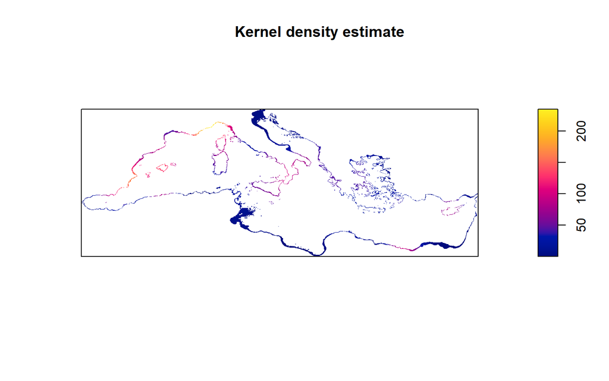

```r
# Create a mask that will be used for kernel density estimtate in spatstat
mask <- myExpl$thetao_median > 0
mask_df <- terra::as.data.frame(mask, na.rm = TRUE, xy=TRUE)

# Spatial window for the point pattern object
owin_obs <- owin(mask = mask_df)

# Create a point pattern object
ppp_obs <- ppp(dataXY[,1], dataXY[,2], window = owin_obs )
ppp_obs
## Planar point pattern: 640 points
## window: binary image mask
## 371 x 1002 pixel array (ny, nx)
## enclosing rectangle: [-5.5625, 36.1875] x [30.29167, 45.75] units

# Calculate points density
density_obs <- spatstat.explore::density.ppp(
  ppp_obs, positive = TRUE, diggle = TRUE, sigma = 1)

# Check density_obs summary
summary(density_obs)
## real-valued pixel image
## 371 x 1002 pixel array (ny, nx)
## enclosing rectangle: [-5.5625, 36.1875] x [30.29167, 45.75] units
## dimensions of each pixel: 0.0417 x 0.04166667 units
## Image is defined on a subset of the rectangular grid
## Subset area = 20.4461827457017 square units
## Subset area fraction = 0.0317
## Pixel values (inside window):
##  range = [0.02706288, 235.1846]
##  integral = 640
##  mean = 31.30169

# Plot density
plot(density_obs, main = "Kernel density estimate" )
```

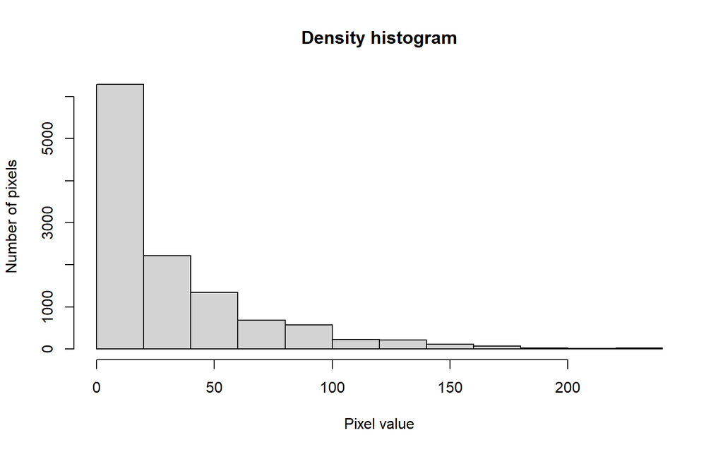

```r
# Plot density histogram
hist(density_obs, main = "Density histogram")
```

P-abs are sampled based on the geographic distribution of the kernel density estimate. Here, n = 500 density-dependent P-abs are generated; for more stable results, a larger number should be used (e.g. n = 5.000). To sample P-abs, the function `spatstat.random::rpoispp` is used. This function by defaults returns the realization of a point process with the same intensity defined in the `lambda` argument. Thus the estimated density is scaled to have the expected number of P-abs returned. The random sampling process is repeated three times and the output is saved in an `sf` object for further processing.

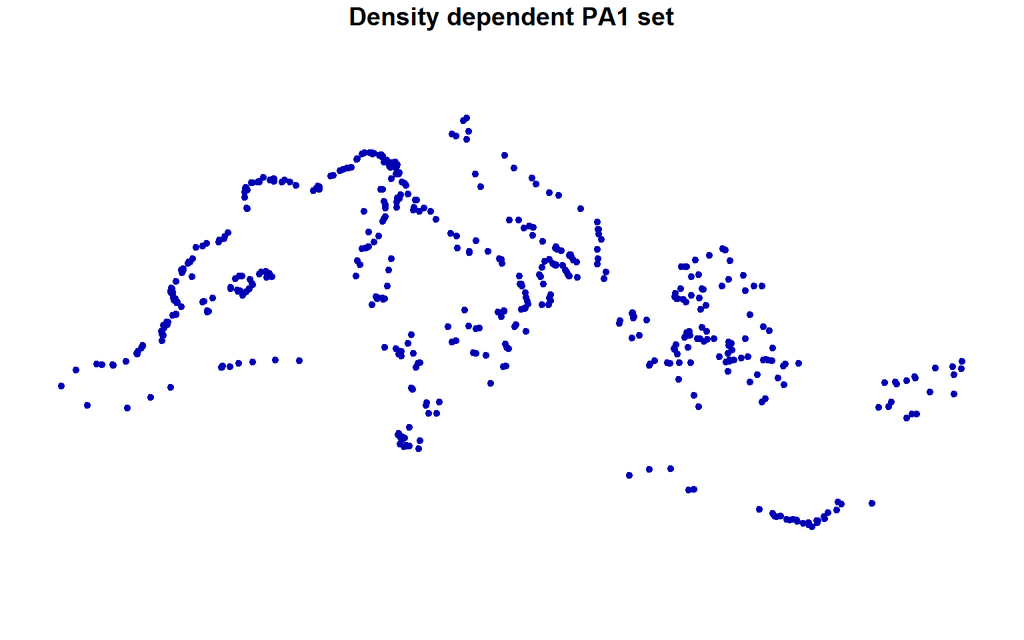

```r
# Decide number of density dependent pseudoabsences
n_pa_dens <- 500

# Adjust dentisy
adjust <- n_pa_dens / ppp_obs$n

# Sample pseudoabsences based on occurrences density kernel
PA1_dens <- rpoispp(density_obs*adjust)
PA2_dens <- rpoispp(density_obs*adjust)
PA3_dens <- rpoispp(density_obs*adjust)

# Transform to sf object
PA_dens_sf <- rbind(
  data.frame(x = PA1_dens$x, y = PA1_dens$y) %>%
    dplyr::mutate(PA1 = TRUE, PA2 = FALSE, PA3 = FALSE),
  data.frame(x = PA2_dens$x, y = PA2_dens$y) %>%
    dplyr::mutate(PA1 = FALSE, PA2 = TRUE, PA3 = FALSE),
  data.frame(x = PA3_dens$x, y = PA3_dens$y) %>%
    dplyr::mutate(PA1 = FALSE, PA2 = FALSE, PA3 = TRUE)
  ) %>%
  st_as_sf(coords = c(1,2), crs = crs(DataSpecies))

# Plot PA1
plot(PA_dens_sf[PA_dens_sf$PA1 == TRUE,]["PA1"],
     pch = 20, main = "Density dependent PA1 set")
```

### 3.1.2 Environmentally Stratified P-abs

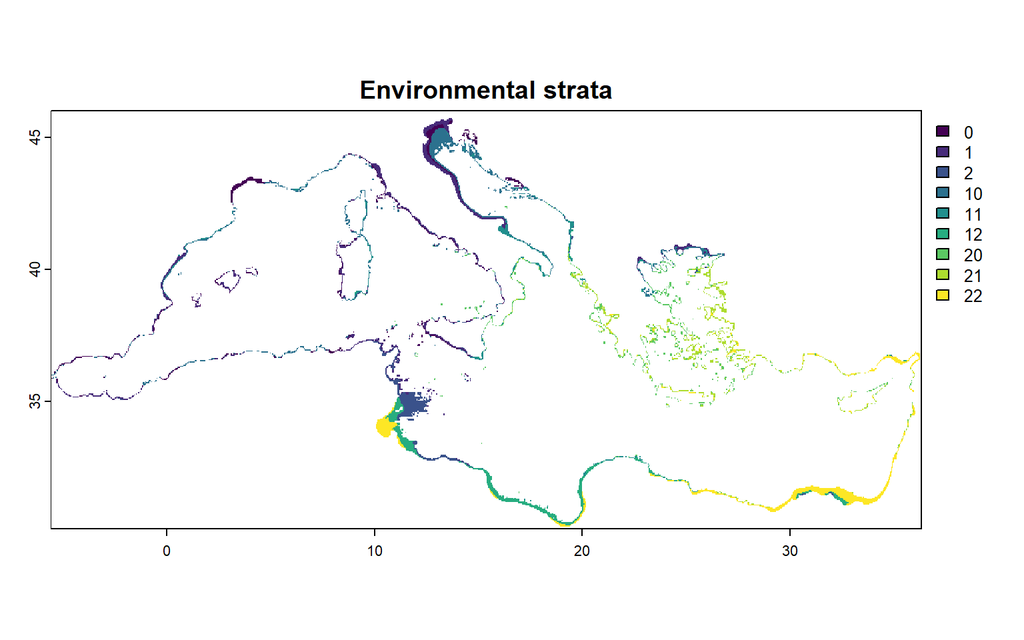

```r
# Number of stratified P-abs
n_pa_env <- 500

# Create reclassified spatraster
myExpl_class <- myExpl

# reclassify each layer (function not vectorized -.-')
breaks <- global(myExpl_class, quantile, probs=c(0, 0.33, 0.66, 1),
                 na.rm=TRUE) %>% as.matrix()

for (n in 1:length(names(myExpl_class))){
  myExpl_class[[n]] <- classify(myExpl_class[[n]],
                                rcl = as.vector(breaks[n,]),
                                include.lowest=FALSE,
                                brackets=TRUE )
}

# Create unique classification
myExpl_class$comb <- myExpl_class$thetao_median + 10 * myExpl_class$so_median
myExpl_class$comb <- as.factor(myExpl_class$comb)

# Check in plot
plot(myExpl_class$comb, main = "Environmental strata")
```

Here, envrionemntally stratified P-abs are sampled using the custom function `stratified_pp_sampler_area`. This function samples an uniform point process for each environmental strata, where the number of P-abs per strata is proportional to its area. n = 500 density-dependent P-abs are generated; for more stable results, a larger number should be used (e.g. n = 5.000). The random sampling process is repeated three times and the output is saved in an `sf` object for further processing.

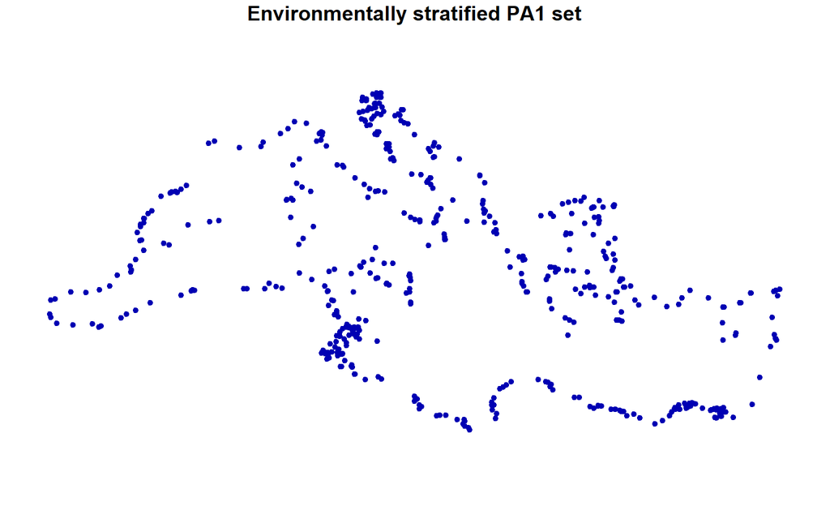

```r
# Sample environmentally stratified pseudoabsences
PA1_env <- stratified_pp_sampler_area(myExpl_class$comb, n_pa_env)
PA2_env <- stratified_pp_sampler_area(myExpl_class$comb, n_pa_env)
PA3_env <- stratified_pp_sampler_area(myExpl_class$comb, n_pa_env)

# transform to sf object
PA_env_sf <- rbind(
  data.frame(x = PA1_env[,1], y = PA1_env[,2]) %>%
    dplyr::mutate(PA1 = TRUE, PA2 = FALSE, PA3 = FALSE),
  data.frame(x = PA2_env[,1], y = PA2_env[,2]) %>%
    dplyr::mutate(PA1 = FALSE, PA2 = TRUE, PA3 = FALSE),
  data.frame(x = PA3_env[,1], y = PA3_env[,2]) %>%
    dplyr::mutate(PA1 = FALSE, PA2 = FALSE, PA3 = TRUE)
) %>%
  st_as_sf(coords = c(1,2), crs = crs(DataSpecies))

# Check with a plot
plot(PA_env_sf[PA_env_sf$PA1 == TRUE,]["PA1"],
     pch = 20, main = "Environmentally stratified PA1 set")
```

### 3.1.3 P-abs dataset generation

The data.frames with P-abs generated in the previous steps are merged and formatted in a biomod-friendly way that will be useful later. The biomod-friendly data are stored in the `PA.user.table` object. An `sf` object is also created, which will be useful for plotting.

```r
# Merge the two p-abs data.frames
PA_full <- rbind(
  st_coordinates(PA_dens_sf) %>% data.frame() ,
  st_coordinates(PA_env_sf) %>% data.frame())

PA_TF_table <- rbind(
  st_drop_geometry(PA_dens_sf) %>% dplyr::select(PA1, PA2, PA3) ,
  st_drop_geometry(PA_env_sf) %>% dplyr::select(PA1, PA2, PA3) )

# Join the information with occurrences to generate the full dataset used to train/evaluate the models
resp <- c(dataResp, rep(NA, nrow(PA_full) ) )
respXY <- rbind(dataXY, data.frame(X = PA_full$X, Y = PA_full$Y))

# Create biomod-friendly data
PA.user.table <- rbind(
   data.frame(PA1 = rep(TRUE, length(dataResp)),
              PA2 = rep(TRUE, length(dataResp)),
              PA3 = rep(TRUE, length(dataResp))),
   PA_TF_table
   )

# Create data frame for creating cross validation folds
PA.user.table_sf <- st_as_sf(
   data.frame(respXY, "resp" = ifelse(is.na(resp), 0, 1), PA.user.table ),
   coords = c("X", "Y"),
   crs = crs(myExpl))
```

## 3.2 Spatial Blocks for Models Evaluation

Then, a spatial block approach is used to split all the data (occurrences and P-abs) in a training (80 %) and evaluation (20 %) datasets. This procedure is needed because no independent evaluation dataset is available. The spatial blocks ensure that training and evaluation data are spatially distinct as much as possible, this testing the ensemble’s ability to generalize over different geographic area. Spatial clusters are created using a k-medoid approach (`cluster::pam` function: see Brun et al. 2020 for details on the method). The function `make_blocks` was developed by Philipp Brun and used in the Brun et al. (2020) paper. If this function is used, the Brun et al. (2020) paper must be cited.

Here, the aim is to split the data into a training and evaluation datasets. Therefore, 5 folds are generated (`cv_param_nstrat`), one of them (fold with the smaller occurrence/P-abs ratio) is assigned to the evaluation set and the four remaining to the training set. Each fold can contain points from 2 geographic clusters (`cv_param_nclusters`). Clustered occurrence and P-abs points can be mapped to be visually inspected.

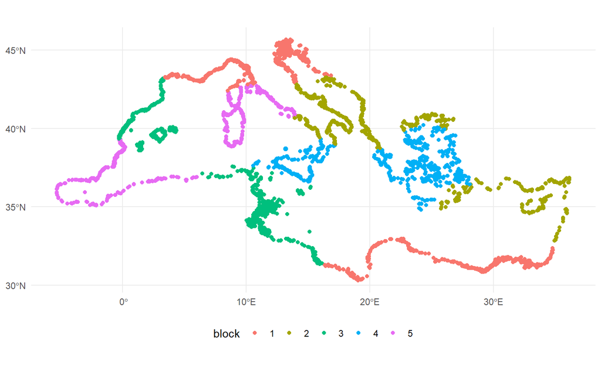

```r
# Number of folds to create
cv_param_nstrat <- 5

# number of clusters from which the algorithm starts creating foldss
cv_param_nclusters <- 10

# Create blocks to split train and test folds and add to pa.user.table dataframe
PA.user.table_sf$block <- make_blocks(
  df = respXY,
  nstrat = cv_param_nstrat,
  nclusters = cv_param_nclusters,
  pres = ifelse(is.na(resp), 0, 1) )

# Select fold to use for evaluation
fold_eval <- PA.user.table_sf %>%
  group_by(block) %>%
  dplyr::summarize(
    n_pres = sum(resp == 1),
    n_abs = sum(resp == 0) ) %>%
  dplyr::mutate(ratio = n_pres / n_abs) %>%
  dplyr::slice( which.min( ratio ) ) %>%
  dplyr::pull(block)

# Add train-evaluation label to PA.user.table_sf
PA.user.table_sf <- PA.user.table_sf %>%
  dplyr::mutate(flag_train_eval = ifelse(block == fold_eval, "eval", "train"))

# Create train and evaluation dataset
PA.user.table_sf_train <- PA.user.table_sf %>%
  dplyr::filter(block != fold_eval)
PA.user.table_sf_eval <- PA.user.table_sf %>%
  dplyr::filter(block == fold_eval)

# Retain only PA from PA1 (for evaluation)
PA.user.table_sf_eval <- PA.user.table_sf_eval %>%
  dplyr::filter(PA1 == TRUE) %>%
  dplyr::select(-PA1, -PA2, -PA3)

# Create PA user table for train data
PA.user.table_train <- PA.user.table[ PA.user.table_sf$block != fold_eval ,]

# Format data for training
resp_train <- resp[ PA.user.table_sf$block != fold_eval ]
respXY_train <- respXY[ PA.user.table_sf$block != fold_eval , ]

# Format data for evaluation
resp_eval <- PA.user.table_sf_eval$resp
respXY_eval <- st_coordinates(PA.user.table_sf_eval)

# Check the spatial blocks
ggplot() +
  theme_minimal() +
  geom_sf(data = PA.user.table_sf, mapping = aes(color = as.factor(block))) +
  scale_color_discrete(name = "block") +
  theme(legend.position = "bottom")
```

The formatted data are then passed to the function `biomod2::BIOMOD_FormatingData`, that stores the data for the next steps. The data can be plotted for visual inspection. Although occurrences and P-abs are used for calibration, validation, and evaluation, the data are stored in a way that the P-abs used for evaluation are recognized as true absences. This is useful for keeping separated the two datasets.

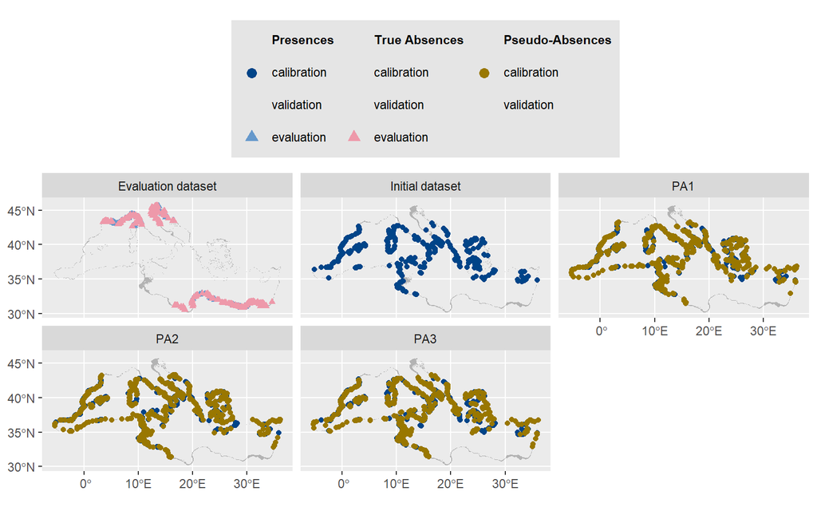

[output not shown]

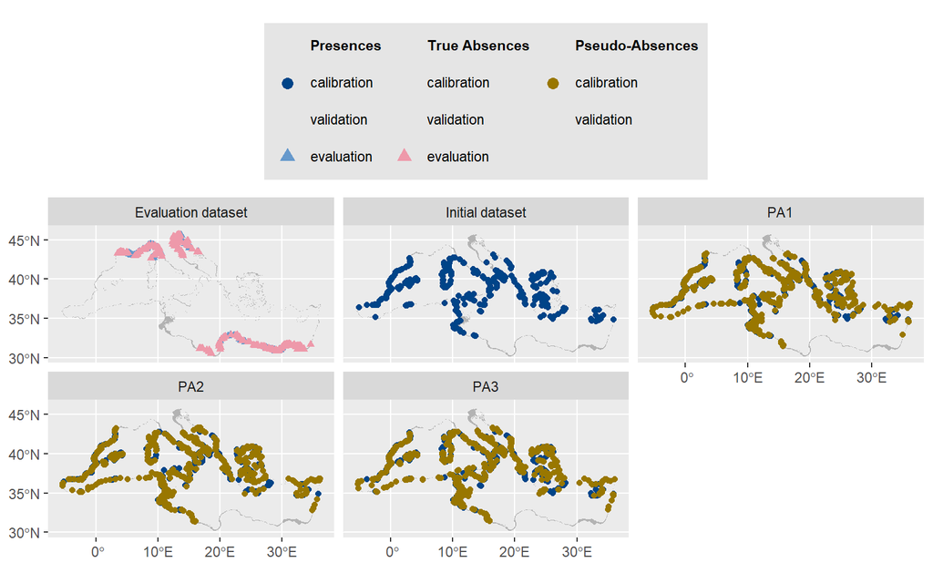

```r
# Format biomod data
myBiomodData <- BIOMOD_FormatingData(
  expl.var = myExpl,
  resp.name = species_name,
  resp.var = resp_train,
  resp.xy = respXY_train,
  eval.resp.var = resp_eval,
  eval.resp.xy = respXY_eval,
  PA.strategy = 'user.defined',
  PA.user.table = PA.user.table_train,
  dir.name = "models")
##
## -=-=-=-=-=-=-=-=-=-=-=-=-=-= posidonia Data Formating -=-=-=-=-=-=-=-=-=-=-=-=-=-=
##
##  !!! Some data are located in the same raster cell.
##           Please set `filter.raster = TRUE` if you want an automatic filtering.
##
## Checking Pseudo-absence selection arguments...
##
##    > User defined pseudo absences selection
##
##  ! Some NAs have been automatically removed from your data
##  !!! Some data are located in the same raster cell.
##           Please set `filter.raster = TRUE` if you want an automatic filtering.
##  !!! Some data are located in the same raster cell.
##           Please set `filter.raster = TRUE` if you want an automatic filtering.
##       ! No data has been set aside for modeling evaluation
##  ! Some NAs have been automatically removed from your data
## -=-=-=-=-=-=-=-=-=-=-=-=-=-=-=-=-=-= Done -=-=-=-=-=-=-=-=-=-=-=-=-=-=-=-=-=-=

# Plot formatted data
plot(myBiomodData)
```

## 3.3 Models Calibration

```r
# Define options for single models
  models.option <- list(

    GLM.binary.stats.glm = list(
      "_PA1_allRun" = list(
        type = 'quadratic',
        test = "AIC"),
      "_PA2_allRun" = list(
        type = 'quadratic',
        test = "AIC") ,
      "_PA3_allRun" = list(
        type = 'quadratic',
        test = "AIC")
    ),

    RF.binary.randomForest.randomForest = list(
      "_PA1_allRun" = list(
        do.classif = TRUE,
        ntree = 500,
        mtry = 2,
        sampsize = c(30, 30),
        replace = TRUE,
        nodesize = 40),
      "_PA2_allRun" = list(
        do.classif = TRUE,
        ntree = 500,
        mtry = 2,
        sampsize = c(30, 30),
        replace = TRUE,
        nodesize = 40),
      "_PA3_allRun" = list(
        do.classif = TRUE,
        ntree = 500,
        mtry = 2,
        sampsize = c(30, 30),
        replace = TRUE,
        nodesize = 40)
    ),

    GAM.binary.mgcv.gam = list(
      "_PA1_allRun" = list(
        gamma = 3),
      "_PA2_allRun" = list(
        gamma = 3),
      "_PA3_allRun" = list(
        gamma = 3)
    ),

    ANN.binary.nnet.nnet = list(
      "_PA1_allRun" = list(
        size = 3,
        decay = 0.05),
      "_PA3_allRun" = list(
        size = 3,
        decay = 0.05),
      "_PA3_allRun" = list(
        size = 3,
        decay = 0.05)
    )
  )

  # Structure options for modelization
  myBiomodOptions <- bm_ModelingOptions(
    data.type = 'binary',
    models = c("GLM", "RF", "GAM", "ANN"),
    user.base = "bigboss",
    strategy = "user.defined",
    user.val = models.option,
    bm.format = myBiomodData
  )
##
## -=-=-=-=-=-=-=-=-=-=-=-=-=-= Build Modeling Options -=-=-=-=-=-=-=-=-=-=-=-=-=-=
##
##  >  GLM options (datatype: binary , package: stats , function: glm )...
##
##  >  RF options (datatype: binary , package: randomForest , function: randomForest )...
##
##  >  GAM options (datatype: binary , package: mgcv , function: gam )...
##
##  >  ANN options (datatype: binary , package: nnet , function: nnet )...
##
##
## -=-=-=-=-=-=-=-=-=-=-=-=-=-=-=-=-=-= Done -=-=-=-=-=-=-=-=-=-=-=-=-=-=-=-=-=-=
```

The models are fitted using the function `biomod2::BIOMOD_Modeling`. Few options are specified in this function In particular, the 5-fold cross validation is specified by setting `CV.strategy = "kfold"`, `CV.nb.rep = 3`, and `CV.k = 5`. The `biomod2` default setting of equal prevalence to presences and P-Abs is set with `prevalence = 0.5` (i.e., the sum of the presences weights equals the sum of P-Abs weights). This way, the influence of P-Abs in the calibration of each single model is kept constant, regardless of the number of presence points used for fitting (useful when several species with different number of occurrences are fitted for instance in a loop).

The procedure to calculate the variable importance is set to be repeated 3 times (`var.import = 3`). The algorithm calculates the importance of predictors in the models and in the ensemble using a permutation approach. Following this method, each predictor is randomly permuted one at a time and model predictions made accordingly. Each prediction is then compared with and without permutation using Pearson’s correlation coefficient (ρ). Predictor importance was determined as 1−|ρ|. This process is repeated three times for each predictor, and the average variable importance is considered.

Another relevant argument is the evaluation metric (`metric.eval`). Here, four metrics are selected: the Area Under the Receiving Operating Curce (ROC), the Cohen’s K (KAPPA), the Boyce’s Index (BOYCE), and the True Skill Statistics (TSS). AUC, TSS, and KAPPA are widely used to assess the performance of classification algorithms. The Boyce’s index is a presence only index and checks weather the model’s output in terms of probability of occurrence (also known as Habitat Suitability Index) has higher values in correspondence of occurrence points (Hierzel et al., 2006)

```r
# Fit single models
  myBiomodModelOut <- BIOMOD_Modeling(
    bm.format = myBiomodData,
    OPT.user = myBiomodOptions,
    modeling.id = 'AllModels',
    models = c("GLM","RF", "GAM", "ANN"),
    CV.strategy = "kfold",
    CV.nb.rep = 3,
    CV.k = 5,
    var.import = 3,
    metric.eval = c('ROC', "TSS", "KAPPA", "BOYCE"),
    prevalence = 0.5,
    do.progress = TRUE)
```

## 3.4 Models Evaluation

Performance metrics (AUC, KAPPA, BOYCE, TSS) are calculated for each model for the calibration, validation, and evaluation data sets. For single models’ assessment, the comparison can be done between calibration and validation metrics. This is done by plotting calibration vs validation metrics in a scatterplot. Values along the 1:1 line represent models with limited overfitting.

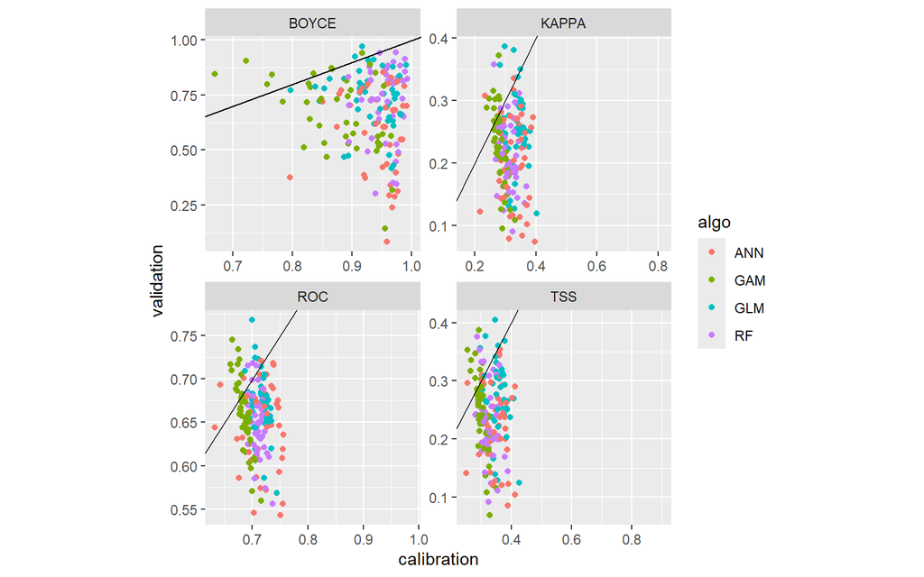

```r
# Plot scatterplot calibration vs evaluation
get_evaluations(myBiomodModelOut) %>%
  ggplot() +
  geom_point(aes(x = calibration, y = validation, color = algo)) +
  facet_wrap(~metric.eval, scales = "free") +
  geom_abline(intercept = 0, slope = 1) +
  theme(aspect.ratio = 1)
```

## 3.5 Models Ensembling

The ensemble is calculated by weight averaging the models based on their AUC score (function `biomod2::BIOMOD_EnsembleModeling`). First, models with low performances (AUC < 0.7, `metric.select.thresh` agument) are removed. Then, a weighted mean of models is created with weights exponential decay exponent of 1.4 (`EMwmean.decay` argument).

```r
# Model ensemble models
myBiomodEM <- BIOMOD_EnsembleModeling(
  bm.mod = myBiomodModelOut,
  models.chosen = 'all',
  em.by = "all",
  em.algo = 'EMwmean',
  metric.select = 'ROC',
  metric.select.thresh = 0.7,
  metric.eval = c( 'ROC', "TSS", "KAPPA", "BOYCE"),
  var.import = 3,
  EMci.alpha = 0.05,
  EMwmean.decay = 1.4,
  do.progress = TRUE)
```

After getting the ensemble done, its performances can be checked.

```r
# Get ensemble performance scores
get_evaluations(myBiomodEM) %>%
  dplyr::select(metric.eval, calibration, evaluation)
##   metric.eval calibration evaluation
## 1         ROC       0.701      0.783
## 2         TSS       0.326      0.420
## 3       KAPPA       0.199      0.415
## 4       BOYCE       0.956      0.900
```

## 3.6 Partial dependency plots and variables importances

Partial dependency plots show how the univariate model response to predictors when all other predictors are fixed to their median values (`biomod2::bm_PlotResponseCurves`). The variable importance score is also included (`biomod2::get_variables_importance`).

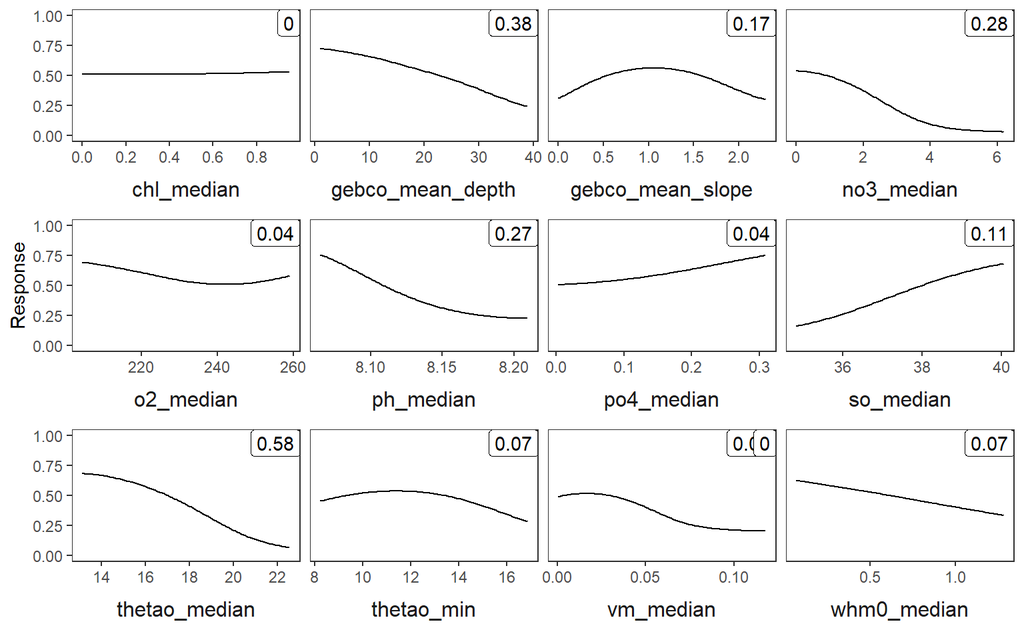

```r
# Calculate partial dependency plots
pdp_df <- bm_PlotResponseCurves(
  bm.out = myBiomodEM,
  models.chosen = get_built_models(myBiomodEM),
  fixed.var = 'median',
  do.progress = FALSE,
  do.plot = FALSE)

# get variable importances
vimp_df <- get_variables_importance(myBiomodEM) %>%
  dplyr::rename(expl.name = expl.var)

# Plot partial dependency plots
pdp_df$tab %>%
  ggplot() +
  theme_bw() +
  geom_line(aes(x = expl.val, y = pred.val ) ) +
  facet_wrap(~expl.name,
             scales = "free_x",
             strip.position = "bottom",
             labeller = "label_parsed") +
  ylab("Response")+
  theme(strip.placement = "outside",
        strip.background = element_blank(),
        axis.title.x = element_blank(),
        panel.grid.major = element_blank(),
        panel.grid.minor = element_blank(),
        strip.text = element_text( size = 12 ) ) +
  geom_label(data = vimp_df,
             mapping = aes(x = Inf, y = Inf, label = round(var.imp,2) ),
             hjust =  1, vjust = 1) +
  ylim(0,1) +
  scale_x_continuous(breaks = scales::pretty_breaks(n = 4))
```

## 3.7 Models Projection

Models can be projected to map the results in a geographic space. First single models are projected (`biomod2::BIOMOD_Projection`), then the ensemble result is calculated again based on the output (`biomod2::BIOMOD_EnsembleForecasting`). Here, the single models and the ensemble are projected to the original environmental covariates layers to generate a distribution map.

```r
# Project single models
myBiomodProj <- BIOMOD_Projection(
  bm.mod = myBiomodModelOut,
  proj.name = "baseline",
  new.env = myExpl,
  models.chosen = 'all',
  metric.binary = c( 'ROC', "TSS"),
  metric.filter = 'all',
  build.clamping.mask = FALSE,
  do.progress = FALSE)

# Project ensemble models
myBiomodEMProj <- BIOMOD_EnsembleForecasting(
  bm.em = myBiomodEM,
  bm.proj = myBiomodProj,
  models.chosen = 'all',
  metric.binary = c( 'ROC', "TSS", "KAPPA"),
  metric.filter = 'all',
  do.progress = FALSE)
```

The final map is a continuous index ranging from 0 to 1000 that can be interpreted as a probability of occurrence. The map can be binarized by selecting a threshold. Different options are available and here the threshold that balances sensitivity and specificity is used.

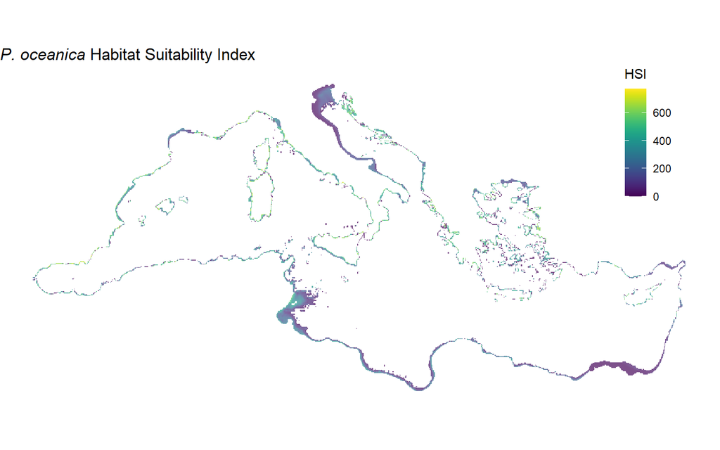

```r
# Plot projection hsi
habitat_rast <- get_predictions(myBiomodEMProj) %>%
  terra::mask(myExpl[[1]])

ggplot() +
  theme_void()+
  ggspatial::layer_spatial(habitat_rast, alpha = 0.7) +
  scale_fill_viridis( na.value = NA,  name = "HSI") +
  ggtitle("*P. oceanica* Habitat Suitability Index ") +
  theme(legend.position = c(0.90, 0.80),
        legend.background = element_blank()) +
  theme(title = element_markdown())
```

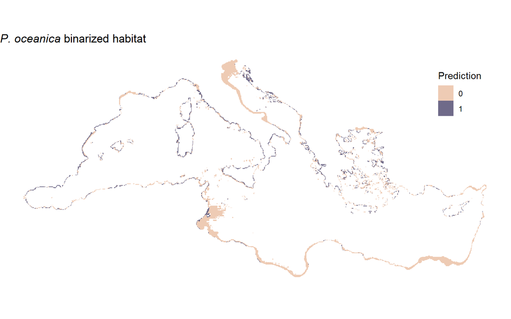

```r
# Plot projection binarized
habitat_rast_bin <- get_predictions(myBiomodEMProj, metric.binary = "TSS") %>%
  terra::mask(myExpl[[1]])

ggplot() +
  theme_void()+
  ggspatial::layer_spatial(as.factor(habitat_rast_bin) , alpha = 0.7) +
  scale_fill_manual(
    values = c("#E6B494", "#312A56"),
    na.value = NA,  name = "Prediction", na.translate = FALSE ) +
  ggtitle("*P. oceanica* binarized habitat") +
  theme(legend.position = c(0.90, 0.80),
        legend.background = element_blank()) +
  theme(title = element_markdown())
```

# 4. Conclusions

The implemented workflow is general and can be used for different species in different geographic context with little modifications.

# References

Elith, J., & Leathwick, J. R. (2009). Species distribution models: ecological explanation and prediction across space and time. Annual review of ecology, evolution, and systematics, 40(1), 677-697.

Pichler, M., & Hartig, F. (2023). Machine learning and deep learning—A review for ecologists. Methods in Ecology and Evolution, 14(4), 994-1016.

Baldan, D., Chauvier‐Mendes, Y., Gianni, F., Cossarini, G., & Bandelj, V. (2024). Identifying Gaps in the Protection of Mediterranean Seagrass Habitats Using Network‐Based Prioritisation. Diversity and Distributions, 30(11), e13922.

Thuiller, W., Lafourcade, B., Engler, R., & Araújo, M. B. (2009). BIOMOD–a platform for ensemble forecasting of species distributions. Ecography, 32(3), 369-373.

Descombes, P., Chauvier, Y., Brun, P., Righetti, D., Wüest, R. O., Karger, D. N., … & Zimmermann, N. E. (2022). Strategies for sampling pseudo-absences for species distribution models in complex mountainous terrain. BioRxiv, 2022-03.

Righetti, D., Vogt, M., Gruber, N., Psomas, A., & Zimmermann, N. E. (2019). Global pattern of phytoplankton diversity driven by temperature and environmental variability. Science advances, 5(5), eaau6253.

Da Re, D., Tordoni, E., Lenoir, J., Lembrechts, J. J., Vanwambeke, S. O., Rocchini, D., & Bazzichetto, M. (2023). USE it: Uniformly sampling pseudo‐absences within the environmental space for applications in habitat suitability models. Methods in Ecology and Evolution, 14(11), 2873-2887.

Brun, P., Thuiller, W., Chauvier, Y., Pellissier, L., Wüest, R. O., Wang, Z., & Zimmermann, N. E. (2020). Model complexity affects species distribution projections under climate change. Journal of Biogeography, 47(1), 130-142.

Hirzel, A. H., Le Lay, G., Helfer, V., Randin, C., & Guisan, A. (2006). Evaluating the ability of habitat suitability models to predict species presences. Ecological modelling, 199(2), 142-152.